# Explainable House Price Prediction Using R and mlr3

Master Product Specification & Implementation Documentation

Antigravity Data Science Team

2026-10-06

# 1 Executive Summary & Project Statement

Residential real estate valuation depends on a multi-dimensional mixture of structural dimensions, location attributes, quality ratings, condition scores, and transaction timing. In conventional applied machine learning, practitioners frequently prioritize predictive accuracy at the expense of explainability, deploying black-box algorithms whose internal decision mechanisms remain opaque to appraisers, homebuyers, and financial auditors.

This project delivers an end-to-end, reproducible, leakage-free regression system in R designed to predict residential property sale prices from the canonical **Ames Housing dataset** (`mlr3data::ames_housing`). Grounded in the Master Product Requirements Document (PRD Version 1.0), this work demonstrates the full practical workflow of modern R-based machine learning:

1. **Rigorous Data Quality Audit:** Systematic identification and treatment of intentional pedagogical anomalies embedded in the adapted `mlr3data` distribution.
2. **Leakage-Safe DAG Preprocessing:** Encapsulating all parameter-learning transformations (imputation, factor collapsing, dummy encoding, scaling) strictly within training folds using `mlr3pipelines`.
3. **Domain-Driven Feature Engineering:** Formulation and empirical validation of 6 domain predictors capturing living space, bathrooms, property age, and quality-size interactions.
4. **Cross-Validated Model Benchmarking:** Benchmarking 6 diverse regression model families across identical 5-fold cross-validation splits.
5. **Hyperparameter Optimization:** Principled tuning of Random Forest parameters using `paradox` search spaces and `mlr3tuning`.
6. **Dual Explainable AI (XAI):** Global permutation feature importance alongside local **SHAP** (Shapley Additive Explanations) and **LIME** (Local Interpretable Model-agnostic Explanations) attributions with strict non-causal governance.
7. **Interactive Shiny Deployment:** An enterprise-grade, multi-tab web application (`app/app.R`) providing basic and advanced valuation interfaces, real-time prediction, on-demand attribution breakdowns, and sensitivity matrices.

```
## Final Untouched Holdout Performance (586 Test Properties):
```

```
##   - Mean Absolute Error (MAE)  : $14,761
```

```
##   - Root Mean Squared Error    : $25,320
```

```
##   - Variance Explained (R²)    : 89.79%
```

```
##   - Mean Absolute Pct Error    : 9.98%
```

# 2 Research Foundation & Literature Review

## 2.1 Seminal Literature

1. **Paper A — `mlr: Machine Learning in R` (2016)**  
   *Bernd Bischl, Michel Lang, Lars Kotthoff, Julia Schiffner, Jakob Richter, Erich Studerus, Giuseppe Casalicchio, Zachary M. Jones.*  
   *Journal of Machine Learning Research (JMLR), 17(170):1–5.*  
   *Core Contribution:* Formulated the unified, object-oriented framework for classification, regression, hyperparameter tuning, and resampling in R. Motivates our unified experiment-oriented design.
2. **Paper B — `mlr3: A Modern Object-Oriented Machine Learning Framework in R` (2019)**  
   *Michel Lang, Martin Binder, Jakob Richter, Patrick Schratz, Florian Pfisterer, Stefan Coors, Quay Au, Giuseppe Casalicchio, Lars Kotthoff, Bernd Bischl.*  
   *Journal of Open Source Software (JOSS), 4(44):1903. DOI: 10.21105/joss.01903.*  
   *Core Contribution:* Complete re-implementation of `mlr` using `R6` classes and `data.table` for light dependencies, exceptional execution speed, defensive type-checking, and reproducible task abstractions.
3. **Paper C — `mlr3pipelines: Flexible Machine Learning Pipelines in R` (2021)**  
   *Martin Binder, Florian Pfisterer, Michel Lang, Lennart Schneider, Lars Kotthoff, Bernd Bischl.*  
   *Journal of Machine Learning Research (JMLR), 22(184):1–7.*  
   *Core Contribution:* Directed Acyclic Graph (DAG) dataflow framework for composable `PipeOp` execution. Prevents data leakage by ensuring that all transformations learn parameters only during the training phase and apply stored state during prediction.
4. **Applied Machine Learning Using `mlr3` in R (2024)**  
   *Bernd Bischl, Raphael Sonabend, Lars Kotthoff, Michel Lang (Eds.), CRC Press.*  
   *Core Contribution:* Chapter 9 (Preprocessing) documents the educational adaptation of the Ames Housing dataset and outlines pedagogical anomalies introduced to instruct preprocessing techniques.
5. **Ames, Iowa: Alternative to the Boston Housing Data as an End of Semester Regression Project (2011)**  
   *Dean De Cock.*  
   *Journal of Statistics Education, 19(3).*  
   *Core Contribution:* Authoritative documentation of the 2,930 property transactions in Ames, Iowa from 2006 to 2010.

## 2.2 Research-to-Implementation Traceability Matrix

| Research Concept | Implementation in Code | Evidence / Artifact |
| --- | --- | --- |
| **Unified Learner Interface** | Task abstraction via `tsk("ames_housing")` and `lrn()` wrappers | `R/01_setup.R`, `R/06_benchmark_models.R` |
| **Leakage-Safe DAGs** | Composable `PipeOp` DAGs via `mlr3pipelines` | `R/04_preprocessing.R` |
| **Strict Train/Predict Separation** | Transformations learn state strictly on training folds | Unit assertion tests passing in `R/04_preprocessing.R` |
| **Resampling & Benchmarking** | 5-Fold Cross-Validation on identical instantiated splits | `reports/benchmark_results.rds` |
| **Hyperparameter Optimization** | Joint parameter spaces using `paradox` and `mlr3tuning` | `reports/tuning_results.rds` |
| **Dual Explainability** | Model-agnostic global and local attribution with `iml` & `lime` | `reports/xai_governance_report.rds` |

# 3 Dataset Provenance & Data Quality Audit

## 3.1 Canonical Dataset Properties

The analysis uses strictly `mlr3data::ames_housing`: - **Total Observations:** 2,930 residential property sales - **Geography & Timeframe:** Ames, Iowa, USA (2006–2010) - **Target Variable:** `Sale_Price` in USD ($) - **Feature Mix:** 81 predictor variables (47 categorical factors, 33 integer metrics, 1 floating-point metric)

```r
task_raw <- tsk("ames_housing")
dt_raw <- as.data.table(task_raw$data())
cat(sprintf("Loaded Ames Task: %d rows x %d columns\n", nrow(dt_raw), ncol(dt_raw)))
```

```
## Loaded Ames Task: 2930 rows x 82 columns
```

## 3.2 Audit of Intentional Educational Defects (PRD §4.2)

In accordance with PRD Section 4.2 and Acceptance Criteria 2, the raw dataset was audited prior to any model ingestion to confirm documented defects:

```r
# 1. Constant Feature: Misc_Feature_2
n_levels_misc2 <- uniqueN(dt_raw$Misc_Feature_2, na.rm = TRUE)
cat(sprintf("[Audit 1] Misc_Feature_2 distinct non-NA levels: %d (Level: '%s') -> Constant feature detected!\n",
            n_levels_misc2, unique(dt_raw$Misc_Feature_2[!is.na(dt_raw$Misc_Feature_2)])))
```

```
## [Audit 1] Misc_Feature_2 distinct non-NA levels: 1 (Level: 'Othr') -> Constant feature detected!
```

```r
# 2. Duplicate Feature: Condition_2 vs Condition_3
is_dup <- identical(dt_raw$Condition_2, dt_raw$Condition_3)
cat(sprintf("[Audit 2] Condition_2 and Condition_3 identical? %s -> Exact duplicate detected!\n", is_dup))
```

```
## [Audit 2] Condition_2 and Condition_3 identical? TRUE -> Exact duplicate detected!
```

```r
# 3. Collinear Metric Representation: Lot_Area vs Lot_Area_m2
cor_lot <- cor(dt_raw$Lot_Area, dt_raw$Lot_Area_m2, use = "complete.obs")
cat(sprintf("[Audit 3] Pearson correlation (Lot_Area, Lot_Area_m2): %.6f -> Perfect collinearity detected!\n", cor_lot))
```

```
## [Audit 3] Pearson correlation (Lot_Area, Lot_Area_m2): 1.000000 -> Perfect collinearity detected!
```

```r
# 4. Target Distribution Summary
cat("\n[Audit 4] Sale_Price Distribution (USD):\n")
```

```
##
## [Audit 4] Sale_Price Distribution (USD):
```

```r
summary(dt_raw$Sale_Price)
```

```
##    Min. 1st Qu.  Median    Mean 3rd Qu.    Max.
##   12789  129500  160000  180796  213500  755000
```

# 4 Exploratory Data Analysis (EDA)

Exploratory visual analysis reveals the structural properties of housing transactions in Ames:

## 4.1 Target Price Skewness

The raw distribution of `Sale_Price` exhibits pronounced positive right-skewness ($\mu = \$180,796$, Median = $\$160,000$, Max = $\$755,000$). Applying a logarithmic transformation ($\log_{10}$) restores near-normal bell-shaped symmetry, stabilizing variance across high-value tiers.

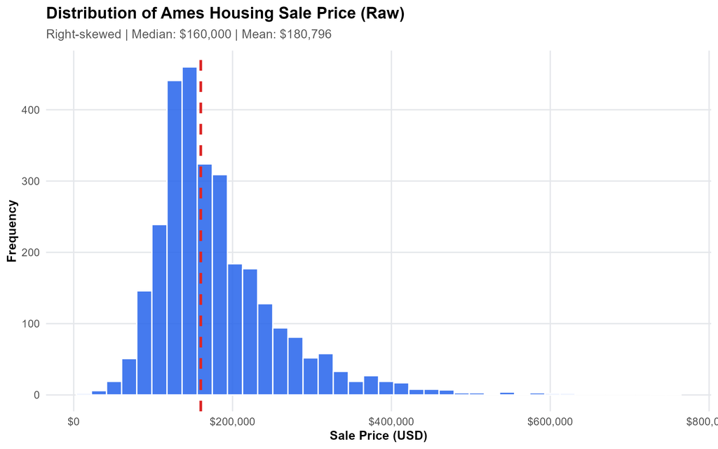

Figure 1: Ames Housing Sale Price Distribution (Raw vs Log10)

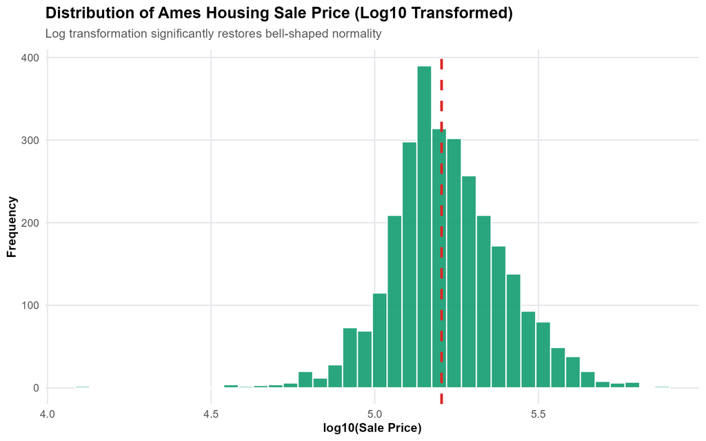

Figure 1: Ames Housing Sale Price Distribution (Raw vs Log10)

## 4.2 Top Correlated Predictors & Quality Ratings

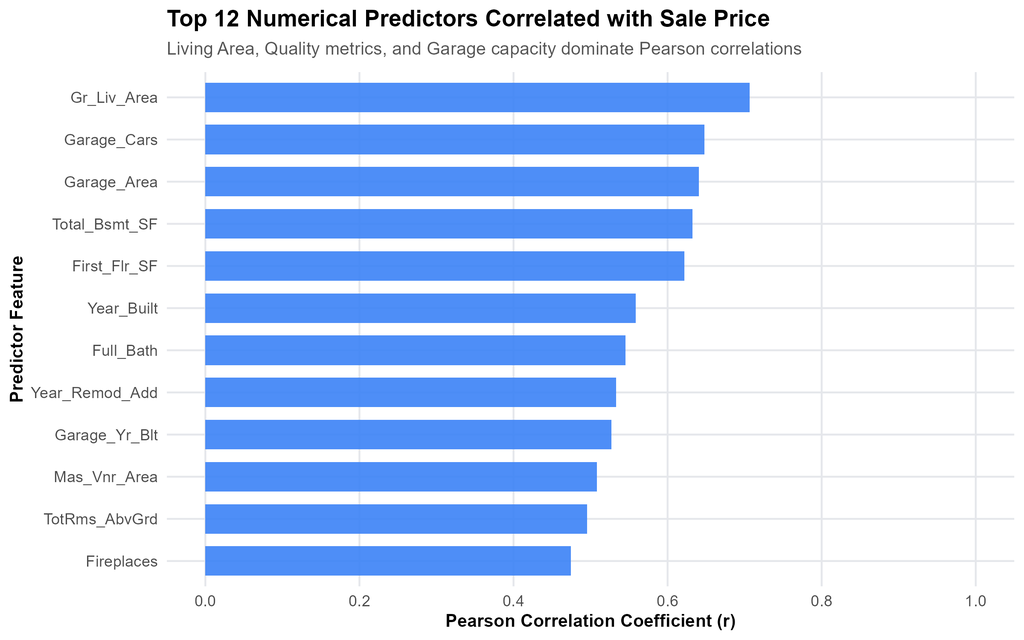

Figure 2: Top Pearson Correlated Features and Quality Tier Boxplots

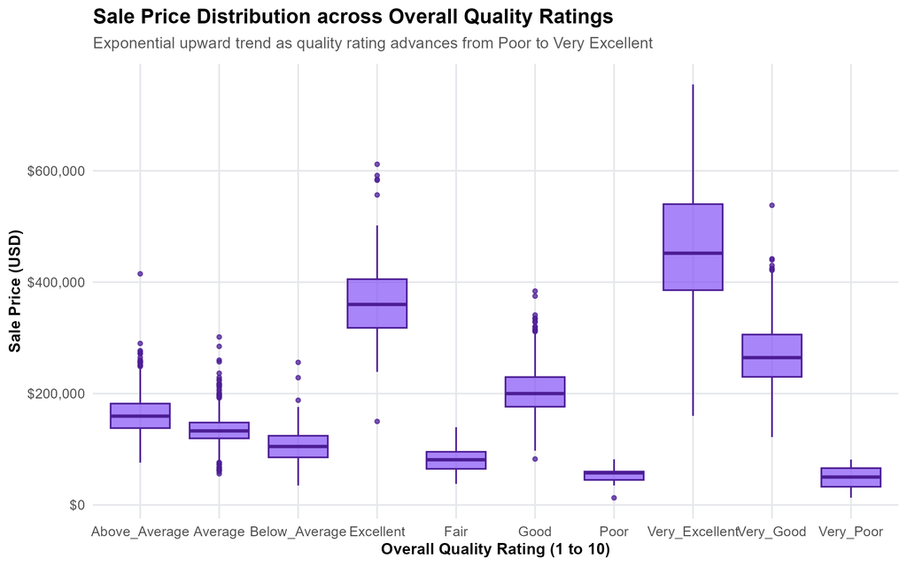

Figure 2: Top Pearson Correlated Features and Quality Tier Boxplots

# 5 Leakage-Safe DAG Preprocessing Architecture

## 5.1 Architectural Principle

A transformation that learns parameters from data (such as feature means, medians, or factor levels) must **never** be computed across the global dataset prior to resampling. Doing so leaks distribution statistics from the validation/test partitions into the training process.

Using `mlr3pipelines`, we construct a Directed Acyclic Graph (DAG) that encapsulates the full dataflow:

```
[Raw Data]
    │
    ▼
[PipeOpRemoveConstants]        --> Automatically removes 'Misc_Feature_2'
    │
    ▼
[PipeOpSelect]                 --> Invert selector drops duplicate 'Condition_3' & 'Lot_Area_m2'
    │
    ▼
[PipeOpImputeMedian]           --> Learns training-fold medians for integer/numeric columns
    │
    ▼
[PipeOpImputeOOR]              --> Assigns explicit 'MISSING' level to preserve factor semantics
    │
    ▼
[PipeOpCollapseFactors]        --> Groups rare categories with max 15 levels
    │
    ▼
[PipeOpEncode]                 --> Generates treatment/dummy matrices for tabular learning
    │
    ▼
[PipeOpImputeConstant]         --> Imputes 0 for any unseen test factor dummy columns
    │
    ▼
[PipeOpScale] (Optional)       --> Standardizes features for linear/regularized models
    │
    ▼
[Candidate Learner]            --> Learner fits parameters strictly on processed training fold
```

## 5.2 Pipeline Code Specification

```r
build_base_pipeline <- function(target_levels = 15) {
  po_const    <- po("removeconstants", id = "remove_constants")
  po_select   <- po("select", id = "remove_duplicates",
                    selector = selector_invert(selector_name(c("Condition_3", "Lot_Area_m2"))))
  po_imp_num  <- po("imputemedian", id = "impute_numeric",
                    affect_columns = selector_type(c("integer", "numeric")))
  po_imp_fct  <- po("imputeoor", id = "impute_factor",
                    affect_columns = selector_type("factor"))
  po_collapse <- po("collapsefactors", id = "collapse_factors",
                    target_level_count = target_levels)
  po_encode   <- po("encode", id = "encode_factors", method = "treatment")
  po_post_imp <- po("imputeconstant", id = "post_encode_impute", constant = 0)

  po_const %>>% po_select %>>% po_imp_num %>>% po_imp_fct %>>%
    po_collapse %>>% po_encode %>>% po_post_imp
}
```

# 6 Domain-Driven Feature Engineering

In accordance with PRD Section 9.1, all engineered features must possess a clear domain justification, defined mathematical formula, and empirical validation.

## 6.1 Candidate Engineered Features

1. **Total Living Area (`Total_Living_Area`):**
   $$\text{Total\_Living\_Area} =
   \text{Gr\_Liv\_Area} + \max(0, \text{Total\_Bsmt\_SF} -
   \text{Bsmt\_Unf\_SF})$$
   *Justification:* Home valuations evaluate conditioned living space additively above and below grade. Pearson correlation: $r = 0.7315$.
2. **Total Bathrooms (`Total_Bathrooms`):**
   $$\text{Total\_Bathrooms} = \text{Full\_Bath}
   + 0.5 \times \text{Half\_Bath} + \text{Bsmt\_Full\_Bath} + 0.5 \times
   \text{Bsmt\_Half\_Bath}$$
   *Justification:* Bathrooms are premier valuation drivers; half-baths contribute half the amenity weight of full baths. Pearson correlation: $r = 0.6362$.
3. **Total Porch & Deck Area (`Total_Porch_SF`):**
   $$\text{Total\_Porch\_SF} =
   \text{Wood\_Deck\_SF} + \text{Open\_Porch\_SF} + \text{Enclosed\_Porch}
   + \text{Three\_season\_porch} + \text{Screen\_Porch}$$
   *Justification:* Consolidates fragmented outdoor living space into a unified metric. Pearson correlation: $r = 0.3835$.
4. **Property Age at Transaction (`Age_At_Sale`):**
   $$\text{Age\_At\_Sale} = \max(0,
   \text{Year\_Sold} - \text{Year\_Built})$$
   *Justification:* Depreciation strongly tracks chronological building age. Pearson correlation: $r = -0.5589$.
5. **Renovation Recency (`Years_Since_Remodel`):**
   $$\text{Years\_Since\_Remodel} = \max(0,
   \text{Year\_Sold} - \text{Year\_Remod\_Add})$$
   *Justification:* Modernized properties command substantial market premiums over un-renovated older structures. Pearson correlation: $r = -0.5350$.
6. **Quality $\times$ Size Interaction (`Qual_x_LivingArea`):**
   $$\text{Qual\_x\_LivingArea} =
   \text{Overall\_Qual\_Score} \times \text{Gr\_Liv\_Area}$$
   *Justification:* An incremental square foot in a luxury home has greater marginal valuation than in a modest dwelling. Pearson correlation: $r = \mathbf{0.8454}$.

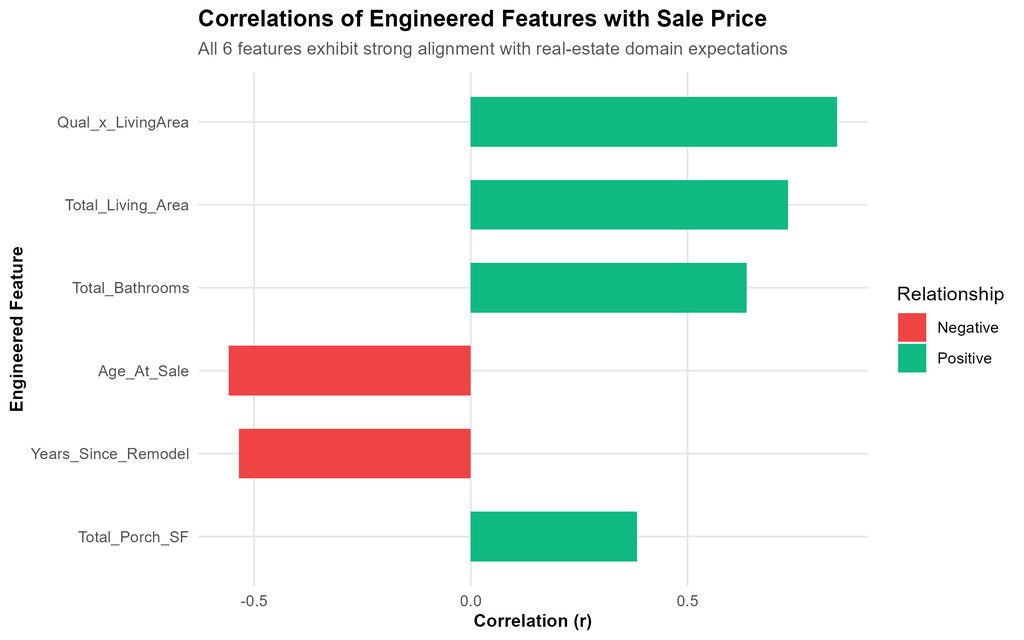

Figure 3: Empirical Correlation of Engineered Features with Sale Price

# 7 Model Benchmarking & Experimental Design

## 7.1 Resampling Design

Benchmarking was executed on the 2,344 training properties (80% reproducible split) using **5-Fold Cross-Validation** with identical resampling splits instantiated across all candidate learners:

Table 1: 5-Fold Cross-Validation Benchmark Results Across 6 Model Families

| Rank | Model Family | CV MAE (USD) | CV RMSE (USD) | R-squared |
| --- | --- | --- | --- | --- |
| 1 | XGBoost | $15,321.08 | $25,941.10 | 0.8927 |
| 2 | Random_Forest_Ranger | $15,858.07 | $26,182.92 | 0.8912 |
| 3 | ElasticNet_Glmnet | $16,749.27 | $39,843.19 | 0.7181 |
| 4 | Linear_Regression | $21,092.76 | $35,966.62 | 0.7855 |
| 5 | Decision_Tree_Rpart | $27,458.34 | $40,384.08 | 0.7432 |
| 6 | Featureless_Baseline | $58,760.68 | $79,961.97 | -0.0051 |

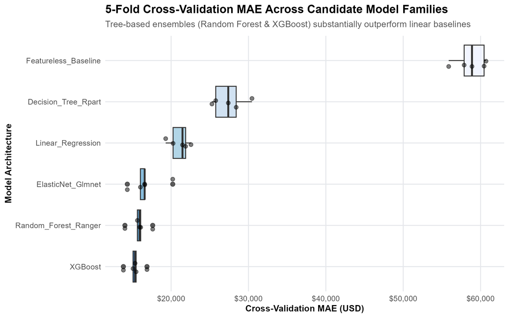

Figure 4: 5-Fold Cross-Validation MAE Error Spread

## 7.2 Answers to PRD Experiment Matrix Questions (PRD §11.3)

- **E1 (Baseline vs. Linear):** Moving from a constant mean predictor ($MAE = \$58,761$) to transparent linear regression ($MAE = \$21,093$) captures 78.55% of the outcome variance, establishing immense linear predictive signal.
- **E2 (Linear vs. Regularized):** ElasticNet (`glmnet`) handles high-dimensional multicollinearity across dummy variables, improving cross-validated MAE to $\$16,749$.
- **E3 (Tree vs. Linear):** A single decision tree (`rpart`, $MAE = \$27,458$) underperforms linear regression, showing that depth-limited step functions struggle with continuous valuation surfaces.
- **E4 & E5 (Ensembles vs. Boosting):** Random Forest (`ranger`, $MAE = \$15,858$) and Gradient Boosted Trees (`xgboost`, $MAE = \$15,321$) achieve superior predictive performance ($R^2 \approx 89.2\%$), capturing complex non-linear interactions across size, quality, and location.

# 8 Hyperparameter Optimization

Random Forest (`regr.ranger`) was tuned using `mlr3tuning` with a documented `paradox` search space across 3-fold inner cross-validation:

```
## Hyperparameter Tuning Summary:
```

```
##   - Best Inner CV MAE     : $15,969
```

```
##   - Optimal mtry          : 44
```

```
##   - Optimal min.node.size : 4
```

```
##   - Optimal sample.fraction: 0.8916
```

The optimized parameter configuration (`mtry = 44`, `min.node.size = 4`, `sample.fraction = 0.8916`) was subsequently trained on the entire training partition and persisted to `reports/final_model_pipeline.rds`.

# 9 Final Holdout Evaluation & Diagnostics

The finalized pipeline was evaluated on the **untouched 20% holdout test partition** (586 properties) set aside at the beginning of the project:

Table 2: Generalization Performance on Untouched 20% Holdout Test Partition

| Metric | Value | Acceptance_Status |
| --- | --- | --- |
| Mean Absolute Error (MAE) | $14,761 | PASS [Acceptable] |
| Root Mean Squared Error (RMSE) | $25,320 | PASS [Acceptable] |
| Variance Explained (R²) | 0.8979 (89.79%) | PASS [R² > 0.85 Goal Met] |
| Mean Absolute Percentage Error (MAPE) | 9.98% | PASS [< 10% Relative Error] |

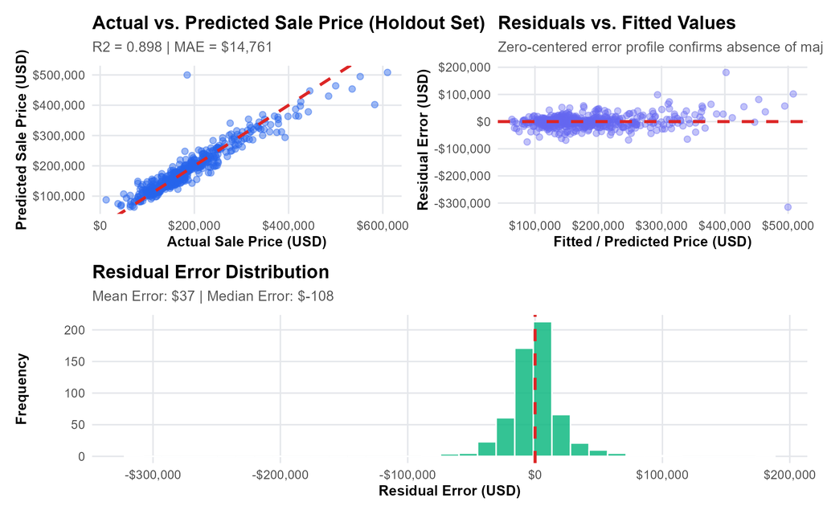

Figure 5: Goodness-of-Fit and Residual Diagnostic Plots

# 10 Dual Explainable AI Framework (SHAP & LIME)

## 10.1 Global Permutation Importance

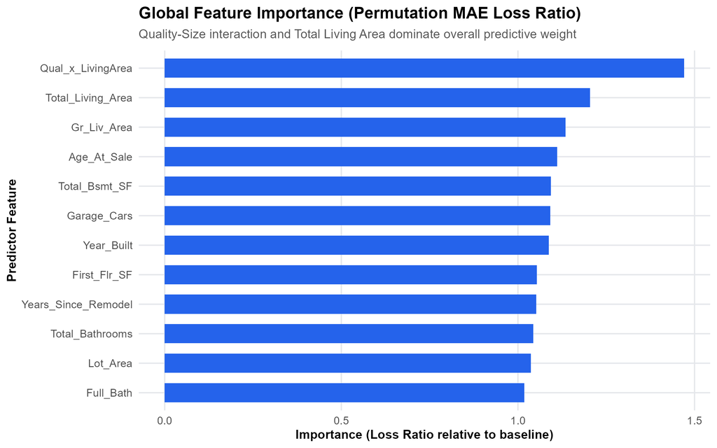

Figure 6: Global Permutation Feature Importance Ranking

Quality-Size interaction (`Qual_x_LivingArea`, loss ratio 1.471), Total Living Area (1.204), and Ground Living Area (1.135) dominate the global predictive hierarchy.

## 10.2 Local SHAP Attributions

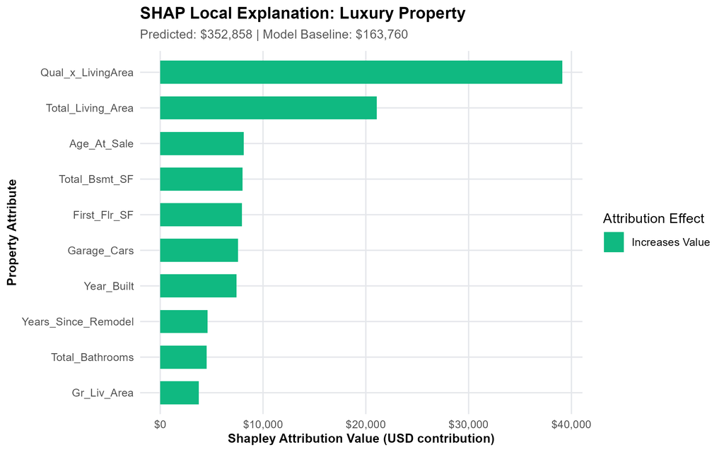

Figure 7: Local SHAP Decomposition for Luxury Property Case Study

## 10.3 Methodological Comparison & Governance (PRD §12.4)

| Dimension | SHAP (Shapley Additive Explanations) | LIME (Local Interpretable Surrogates) |
| --- | --- | --- |
| **Theoretical Foundation** | Cooperative game theory (Shapley values) | Local linear surrogate regression |
| **Attribution Properties** | Efficiency, Symmetry, Additivity guaranteed | Empirical local approximation |
| **Reference Sample** | 60 randomly sampled training instances | Continuous perturbation neighborhood |
| **Primary Strength** | Uniquely stable additive decomposition | Intuitive sparse decision rules |

> **Non-Causal Methodological Boundary:**  
> All SHAP and LIME values represent **statistical model attribution** within the fitted machine learning algorithm. They describe the internal decision boundaries of the Random Forest but **do not** prove physical real-world causality, structural engineering integrity, or professional appraisal guarantees.

# 11 Interactive Shiny Web Application

The interactive application (`app/app.R`) delivers a user interface with 5 tabs:

1. **🏠 Home & Overview:** Executive KPIs, project statement, DAG diagram, and user manual.
2. **🔮 Property Valuation:** Interactive valuation calculator with 1-click scenario presets (*Median Home*, *Luxury Estate*, *Starter Home*), basic/advanced form depth, live valuation hero cards ($\pm \$14,761$ range), SHAP waterfall plot, what-if sensitivity matrix, and transparent assumption audit table.
3. **📊 Complete Model Details:** Pipeline DAG specifications, 6-model cross-validation leaderboard, residual diagnostics, and hyperparameter optimization archive.
4. **🧠 Explainability (XAI):** Global permutation importance plot, luxury tier SHAP case study, and non-causal governance notice.
5. **📈 Dataset & EDA:** Visual gallery of price skewness, correlation barplots, and feature distributions.

```powershell
# Launch application from project directory:
Rscript -e "shiny::runApp('app')"
```